# Fig3:Noise in GFP decay

#combined df with the decay parameters and cellular features

```r
aic.df.allreps <- aic.df %>%
  filter(red == "pup1-rfp", treatment %in% c("none"),
         degron %in% c("cln2.3","cln2.2","mODC.2",
                       "stable","stable.2","stable.3") ) %>%
  filter(ifelse(degron %in% c( "stable.2", "stable", "stable.3"), dy < 0.1, dy < 0.5)) %>%
  group_by(cell.id) %>%
  filter(model == "dy.dm.f", dm > 0.000015) %>% #changed dy.dm model to dy.dm.f
  # left_join(.,pup1.cell.attr , by = c("cell.id","degron","red", "treatment", "exp.field","colony")) %>%
  left_join(.,pup1.proInhi.attr , by = c("cell.id","degron","red", "treatment", "exp.field","colony")) %>%
  mutate(colony = case_when(degron == "cln2.2" & colony == "Replicate 1"~ "Replicate 4",
                            degron == "cln2.2" & colony == "Replicate 2"~ "Replicate 5",
                            degron == "cln2.2" & colony == "Replicate 3"~ "Replicate 6",
                            degron == "cln2" & colony == "Replicate 1"~ "Replicate 7",
                            degron == "cln2" & colony == "Replicate 2"~ "Replicate 8",
                            degron == "cln2" & colony == "Replicate 3"~ "Replicate 9",
                            degron == "cln2.4" & colony == "Replicate 1"~ "Replicate 10",
                            degron == "cln2.4" & colony == "Replicate 2"~ "Replicate 11",
                            degron == "cln2.4" & colony == "Replicate 3"~ "Replicate 12",
                            degron == "mODC" & colony == "Replicate 1"~ "Replicate 4",
                            degron == "mODC" & colony == "Replicate 2"~ "Replicate 5",
                            degron == "mODC" & colony == "Replicate 3"~ "Replicate 6",
                            degron == "stable" & colony == "Replicate 1"~ "Replicate 4",
                            degron == "stable" & colony == "Replicate 2"~ "Replicate 5",
                            degron == "stable" & colony == "Replicate 3"~ "Replicate 6",
                            degron == "stable.3" & colony == "Replicate 1"~ "Replicate 7",
                            degron == "stable.3" & colony == "Replicate 2"~ "Replicate 8",
                            degron == "stable.3" & colony == "Replicate 3"~ "Replicate 9",
                            TRUE ~ colony)) %>%
  filter(degron %in% c("mODC.2","cln2.3","cln2.4")) %>%
  mutate(rfp.mean.bg.sub.puncta = ifelse(is.na(rfp.mean.bg.sub.puncta), 0, rfp.mean.bg.sub.puncta)) %>%
  filter(rfp.mean.bg.sub.puncta > 0) %>%
  mutate(colony = case_when(degron == "stable.3" & colony == "Replicate 7"~ "Replicate 4",
                            degron == "stable.3" & colony == "Replicate 8"~ "Replicate 5",
                            degron == "stable.3" & colony == "Replicate 9"~ "Replicate 6",
                            degron == "cln2.4" & colony == "Replicate 10" ~ "Replicate 4",
                            degron == "cln2.4" & colony == "Replicate 11" ~ "Replicate 5",
                            degron == "cln2.4" & colony == "Replicate 12" ~ "Replicate 6",
                            TRUE ~ colony))

# aic.df.allreps %>%
#   mutate(t.half = log(2)/dy) %>%
#   filter(t.half > 50)
```

#timeseries dataset

```r
timeseries.df <- read.csv("../../../data/paper_pup1_timeseries.csv")
```

Total no. of cells in each degron

| degron | n |
| --- | --- |
| yeGFP-CLN2 | 1248 |
| yeGFP-mODC | 1413 |

adding the half life estimate to each. Formula: t.half = log(2)/dy

| cell.id | f | dy | dm | value | degron | red | treatment | model | aic | exp.field | colony | gfp.mean.bg.af.sub.new | area | Elip_B | Elip_C | no.of.voxels | pos.x | pos.y | spheracity | rfp.mean.bg.sub.puncta | rfp.sum.bg.sub.puncta | dapi.sum.bg.sub.puncta | dapi.mean.bg.sub.puncta | t.half |
| --- | --- | --- | --- | --- | --- | --- | --- | --- | --- | --- | --- | --- | --- | --- | --- | --- | --- | --- | --- | --- | --- | --- | --- | --- |
| 1000001755_20min_s4_mODC.2_pup1-rfp_none | 0.000000e+00 | 0.10561995 | 7.447527e-02 | 0.014362551 | yeGFP-mODC | pup1-rfp | none | dy.dm.f | -231.9907 | 20min_s4 | 1 | 450.34802 | 883.033 | 12.4370 | 12.8659 | 401 | 970.8820 | 975.8990 | 0.451209 | 124.62792 | 17572.5932 | 16357.7495 | 116.01217 | 6.562654 |
| 1000001758_20min_s4_mODC.2_pup1-rfp_none | 0.000000e+00 | 0.08071131 | 2.157176e-01 | 0.038202065 | yeGFP-mODC | pup1-rfp | none | dy.dm.f | -201.6644 | 20min_s4 | 1 | 348.69702 | 2253.530 | 19.7248 | 21.4357 | 1059 | 1004.1500 | 987.8810 | 0.344032 | 96.03692 | 10179.9212 | 7822.7337 | 73.79917 | 8.587981 |
| 1000001759_20min_s4_mODC.2_pup1-rfp_none | 0.000000e+00 | 0.12294773 | 4.870896e-01 | 0.065034428 | yeGFP-mODC | pup1-rfp | none | dy.dm.f | -185.1716 | 20min_s4 | 1 | 544.46402 | 2328.160 | 19.4777 | 22.7798 | 1081 | 980.5110 | 1025.2300 | 0.340055 | 211.94492 | 37090.3604 | 35115.0792 | 200.65717 | 5.637739 |
| 1000001761_20min_s4_mODC.2_pup1-rfp_none | 0.000000e+00 | 0.09594754 | 2.724654e-01 | 0.021179278 | yeGFP-mODC | pup1-rfp | none | dy.dm.f | -219.9503 | 20min_s4 | 1 | 380.91602 | 2691.520 | 21.2389 | 23.8917 | 1271 | 1149.9900 | 862.1700 | 0.325995 | 134.05392 | 23325.4555 | 30067.3930 | 172.80117 | 7.224231 |
| 1000001762_20min_s4_mODC.2_pup1-rfp_none | 0.000000e+00 | 0.10256544 | 8.736190e-01 | 0.035359419 | yeGFP-mODC | pup1-rfp | none | dy.dm.f | -204.0615 | 20min_s4 | 1 | 586.52202 | 1556.440 | 16.0122 | 18.0401 | 723 | 1124.2500 | 887.6070 | 0.383782 | 142.21092 | 20905.0228 | 35578.8665 | 242.03317 | 6.758097 |
| 1000001766_20min_s4_mODC.2_pup1-rfp_none | 0.000000e+00 | 0.16801136 | 3.107458e-02 | 0.017553596 | yeGFP-mODC | pup1-rfp | none | dy.dm.f | -225.7710 | 20min_s4 | 1 | 376.39902 | 2759.370 | 21.3435 | 24.3755 | 1304 | 1095.2700 | 971.7810 | 0.323608 | 152.10292 | 31485.3177 | 16990.0365 | 82.07717 | 4.125597 |
| 1000001767_20min_s4_mODC.2_pup1-rfp_none | 0.000000e+00 | 0.13530003 | 5.010804e-01 | 0.029112577 | yeGFP-mODC | pup1-rfp | none | dy.dm.f | -210.0877 | 20min_s4 | 1 | 296.97402 | 1400.120 | 14.4361 | 17.8946 | 647 | 1077.3300 | 1007.7300 | 0.395420 | 117.04892 | 15450.4490 | 26413.5740 | 200.10317 | 5.123038 |
| 1000001773_20min_s4_mODC.2_pup1-rfp_none | 0.000000e+00 | 0.08955707 | 4.127280e+02 | 0.037615951 | yeGFP-mODC | pup1-rfp | none | dy.dm.f | -202.1437 | 20min_s4 | 1 | 162.55802 | 1632.750 | 13.1691 | 23.6466 | 738 | 1168.7500 | 1030.5300 | 0.374963 | 104.54792 | 1463.6688 | 2566.6063 | 183.32917 | 7.739726 |
| 1000001775_20min_s4_mODC.2_pup1-rfp_none | 0.000000e+00 | 0.11396589 | 8.647759e-01 | 0.009970670 | yeGFP-mODC | pup1-rfp | none | dy.dm.f | -243.3049 | 20min_s4 | 1 | 347.72602 | 1862.580 | 17.8983 | 19.5482 | 870 | 863.9030 | 990.6120 | 0.363663 | 153.13692 | 21132.8785 | 40012.6910 | 289.94717 | 6.082058 |
| 1000001776_20min_s4_mODC.2_pup1-rfp_none | 0.000000e+00 | 0.10364796 | 4.482646e-01 | 0.016031166 | yeGFP-mODC | pup1-rfp | none | dy.dm.f | -228.5834 | 20min_s4 | 1 | 418.40402 | 2858.650 | 22.1995 | 24.2660 | 1352 | 1121.2000 | 743.5500 | 0.320287 | 131.12392 | 29896.3210 | 26418.4460 | 115.87017 | 6.687514 |

[output cut: 990 more lines]

#change in gfp CV

| degron | image.no | cv | n.cell | time.min | mean.gfp | norm.gfp | norm.cv | norm.cv2 |
| --- | --- | --- | --- | --- | --- | --- | --- | --- |
| yeGFP-mODC | 1 | 0.3831922 | 1413 | 0.000 | 393.23212 | 1.00000000 | 1.000000 | 1.000000 |
| yeGFP-mODC | 2 | 0.3950004 | 1413 | 0.898 | 366.06578 | 0.92719662 | 1.030815 | 1.062580 |
| yeGFP-mODC | 3 | 0.4014254 | 1413 | 1.680 | 346.83505 | 0.87665116 | 1.047582 | 1.097428 |
| yeGFP-mODC | 4 | 0.4122034 | 1413 | 2.450 | 330.16729 | 0.83144962 | 1.075709 | 1.157150 |
| yeGFP-mODC | 5 | 0.4195620 | 1413 | 3.250 | 313.74067 | 0.78841803 | 1.094913 | 1.198834 |
| yeGFP-mODC | 6 | 0.4248746 | 1413 | 4.030 | 300.29351 | 0.75413632 | 1.108777 | 1.229386 |
| yeGFP-mODC | 7 | 0.4328122 | 1413 | 4.820 | 284.14015 | 0.71192814 | 1.129491 | 1.275750 |
| yeGFP-mODC | 8 | 0.4483036 | 1413 | 5.610 | 265.39404 | 0.66137462 | 1.169918 | 1.368709 |
| yeGFP-mODC | 9 | 0.4570808 | 1413 | 6.400 | 249.84217 | 0.62121180 | 1.192824 | 1.422829 |
| yeGFP-mODC | 10 | 0.4614991 | 1413 | 7.180 | 237.54270 | 0.59087084 | 1.204354 | 1.450469 |

[output cut: 52 more lines]

##gfp mean change

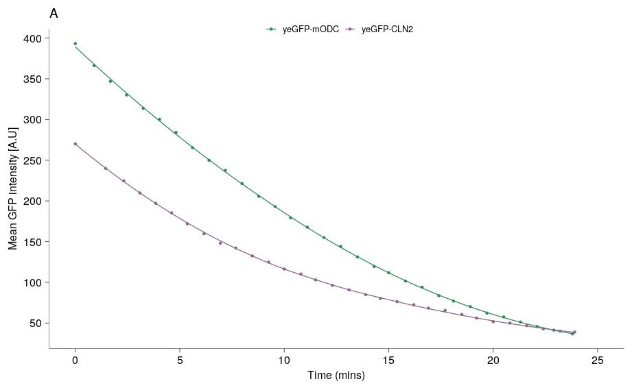

```r
mean.gfp.plt <- cv.df %>%
  ggplot(.,aes(x = time.min, y = mean.gfp, color = degron))+
  geom_point(size = 0.4)+
  geom_smooth(size = 0.3, se = F)+
  # facet_wrap(~degron, scales = "free")+
  ylab("Mean GFP intensity [A.U]")+
  xlab("Time (mins)")+
  theme_pubr()+
  # guides(color = "none")+
  theme(text = element_text(size = 8),
        strip.background = element_blank(),
        legend.background = element_blank(),
        legend.direction = "horizontal",
        legend.position = c(0.5,1),
        legend.key.size = unit(3,"mm"),
        axis.line = element_line(size = 0.1),
        axis.ticks = element_line(size = 0.2))+
  scale_color_manual(values = c("seagreen4","plum4"), name = NULL)+
   scale_x_continuous(breaks = c(0,5,10,15,20,25), limits = c(0,25))+
  scale_y_continuous(breaks = seq(0,400, by = 50))+
  labs(title = "A")

mean.gfp.plt
```

##mean norm gfp

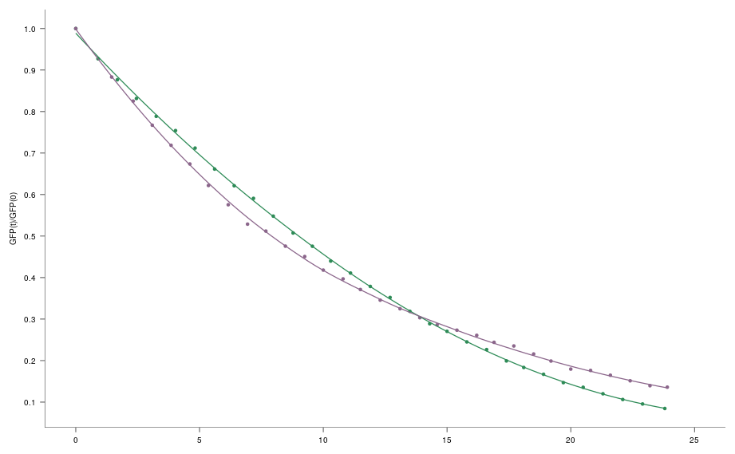

```r
mean.norm.gfp.plt <- cv.df %>%
  ggplot(.,aes(x = time.min, y = norm.gfp, color = degron))+
  geom_point(size = 0.4)+
  geom_smooth(size = 0.3, se = F)+
  # facet_wrap(~degron, scales = "free")+
  ylab(TeX("GFP(t)/GFP(0)"))+
  xlab("Time (mins)")+
  theme_pubr()+
  guides(color = "none")+
  theme(text = element_text(size = 5),
        strip.background = element_blank(),
        legend.background = element_blank(),
        legend.direction = "horizontal",
        legend.position = "none",
        axis.title.x = element_blank(),
        # legend.key.size = unit(3 ,"mm"),
        axis.line = element_line(size = 0.1),
        axis.ticks = element_line(size = 0.2))+
  scale_color_manual(values = c("seagreen4","plum4"), name = NULL)+
   scale_x_continuous(breaks = c(0,5,10,15,20,25), limits = c(0,25))+
  scale_y_continuous(breaks = seq(0,1, by = 0.1))
  # labs(title = "A.1")

mean.norm.gfp.plt
```

Combine the above two plots

```r
reduc.gfp.plt <- mean.gfp.plt+inset_element(mean.norm.gfp.plt,
                           top = 0.9, right = 1,
                           left = 0.39, bottom = 0.45)
```

|  | t | l | b | r |
| --- | --- | --- | --- | --- |
| 1: | 1 | 1 | 1 | 1 |
| 2: | 1 | 2 | 1 | 2 |

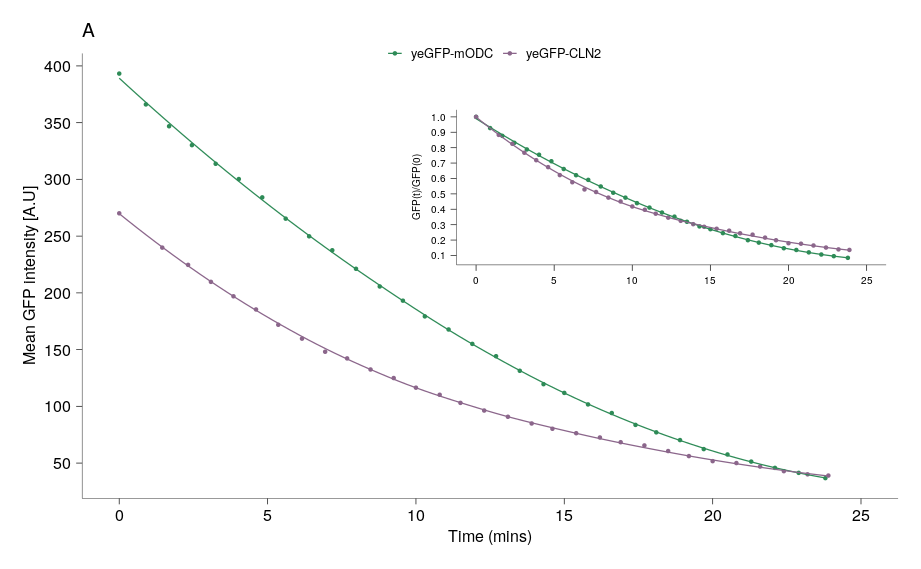

```r
reduc.gfp.plt
```

#Fitting the change in noise in gfp vs time ##Equations ###mechanistic Eq CV(t) in GFP intensity

```r
noise.cvt.fn <- function(cv0,cvd, md,t){
  #cv0 = gfp expression cv,
  #cvd = decay rate CV,
  #md = mean decay rate
  cvt <- (-1+(1+cv0^2)*((1+(cvd^2)*md*t)^(2/cvd^2))*((1+2*(cvd^2)*md*t)^-(1/cvd^2)))/(cv0^2)
  return(cvt)
}
```

##Calculating the CV<sup>2(t)/CV</sup>2(0) using the exeprimental values

```r
cv.1 <- cv.hl.df %>% #this df is for the values at first timepoint and estimated rates of decay
  group_by(degron) %>%
  summarise(cv.gfp.0 = sd(gfp.mean.bg.af.sub.new)/mean(gfp.mean.bg.af.sub.new),
            cv.d = sd(dy)/mean(dy),
            cv.t.half = sd(t.half)/mean(t.half),
            mean.d = mean(dy),
            gfp.cor = cor(gfp.mean.bg.af.sub.new, dy)) %>%
  mutate_if(is.numeric, signif, digits = 4)

#estimating the cv^2(t)/cv^2(0)
mechanistic.cvt <- cv.df %>% #this is the dataframe with cv(t) in GFP over time
  left_join(.,cv.1, by = "degron") %>% #Combine with the data with the initial CV0 and CVd, mean decay rate
  group_by(degron) %>%
  mutate(`0.211.cvd` = noise.cvt.fn(cv0 = cv.gfp.0,
                                cvd = cv.d,
                                md = mean.d,
                                t = time.min))
mechanistic.cvt
```

| degron | image.no | cv | n.cell | time.min | mean.gfp | norm.gfp | norm.cv | norm.cv2 | cv.gfp.0 | cv.d | cv.t.half | mean.d | gfp.cor | 0.211.cvd |
| --- | --- | --- | --- | --- | --- | --- | --- | --- | --- | --- | --- | --- | --- | --- |
| yeGFP-mODC | 1 | 0.3831922 | 1413 | 0.000 | 393.23212 | 1.00000000 | 1.000000 | 1.000000 | 0.3832 | 0.2113 | 0.2260 | 0.1050 | -0.4074 | 1.000000 |
| yeGFP-mODC | 2 | 0.3950004 | 1413 | 0.898 | 366.06578 | 0.92719662 | 1.030815 | 1.062580 | 0.3832 | 0.2113 | 0.2260 | 0.1050 | -0.4074 | 1.003075 |
| yeGFP-mODC | 3 | 0.4014254 | 1413 | 1.680 | 346.83505 | 0.87665116 | 1.047582 | 1.097428 | 0.3832 | 0.2113 | 0.2260 | 0.1050 | -0.4074 | 1.010689 |
| yeGFP-mODC | 4 | 0.4122034 | 1413 | 2.450 | 330.16729 | 0.83144962 | 1.075709 | 1.157150 | 0.3832 | 0.2113 | 0.2260 | 0.1050 | -0.4074 | 1.022589 |
| yeGFP-mODC | 5 | 0.4195620 | 1413 | 3.250 | 313.74067 | 0.78841803 | 1.094913 | 1.198834 | 0.3832 | 0.2113 | 0.2260 | 0.1050 | -0.4074 | 1.039501 |
| yeGFP-mODC | 6 | 0.4248746 | 1413 | 4.030 | 300.29351 | 0.75413632 | 1.108777 | 1.229386 | 0.3832 | 0.2113 | 0.2260 | 0.1050 | -0.4074 | 1.060385 |
| yeGFP-mODC | 7 | 0.4328122 | 1413 | 4.820 | 284.14015 | 0.71192814 | 1.129491 | 1.275750 | 0.3832 | 0.2113 | 0.2260 | 0.1050 | -0.4074 | 1.085901 |
| yeGFP-mODC | 8 | 0.4483036 | 1413 | 5.610 | 265.39404 | 0.66137462 | 1.169918 | 1.368709 | 0.3832 | 0.2113 | 0.2260 | 0.1050 | -0.4074 | 1.115757 |
| yeGFP-mODC | 9 | 0.4570808 | 1413 | 6.400 | 249.84217 | 0.62121180 | 1.192824 | 1.422829 | 0.3832 | 0.2113 | 0.2260 | 0.1050 | -0.4074 | 1.149911 |
| yeGFP-mODC | 10 | 0.4614991 | 1413 | 7.180 | 237.54270 | 0.59087084 | 1.204354 | 1.450469 | 0.3832 | 0.2113 | 0.2260 | 0.1050 | -0.4074 | 1.187812 |

[output cut: 52 more lines]

##Fitting the parameters of the cvt equations fitting the data to the mechanistic change in CV for initial CV(0) in GFP intensity

```r
library(optimx)

cvt.opt.fn<- function(df1, par){
  #fitting for the CV in gfp at t = 0
  cv0.a <- par[1] #gfp cv0
  # cvd.b <- par[2] #cv decay rate

  mech.cv.df <- df1 %>%
    mutate(mech.cvt2 = noise.cvt.fn(cv0 = cv0.a,
                                    cvd = cv.d,
                                    md = mean.d,
                                    t = time.min),
           cvt2.err = (norm.cv2 - mech.cvt2)^2) %>%
    summarise(sum.err = sum(cvt2.err))

  return(mech.cv.df$sum.err)
}

#Split the dataframe based on the degron
list.cvt.opt <- cv.df %>%
  left_join(.,cv.1, by = "degron") %>%
  split(.$degron)


#Run the optimization
cvt.fits <- lapply(c(1,2), function(a){

  df <- list.cvt.opt[[a]]

  par.optim <- c(0.2) #Initial values for minimizationcv.gfp at t=0

  names(par.optim) <- c("gfp.cv0")

  optimx(par = par.optim,
         fn = cvt.opt.fn,
         method = "L-BFGS-B",
         lower = c(0.1),
         upper = c(0.8),
         df1 = df,
         itnmax = 100000)
})


#Making dataframes
#without cor
cvt.fits.df <- cvt.fits %>% bind_rows(.id = "degron") %>%
  mutate(degron = case_when(degron == "1" ~ "yeGFP-mODC",
                            degron == "2" ~ "yeGFP-CLN2"))



cvt.fits.df
```

|  | degron | gfp.cv0 | value | fevals | gevals | niter | convcode | kkt1 | kkt2 | xtime |
| --- | --- | --- | --- | --- | --- | --- | --- | --- | --- | --- |
| L-BFGS-B...1 | yeGFP-mODC | 0.2527840 | 0.7615387 | 27 | 27 | NA | 0 | FALSE | TRUE | 0.273 |
| L-BFGS-B...2 | yeGFP-CLN2 | 0.6228739 | 0.2941161 | 13 | 13 | NA | 0 | TRUE | TRUE | 0.131 |

###Calculating the CV<sup>2(t)/CV</sup>2(0) using the fitted values of CV0 and Corr

```r
mechanistic.cvt <- cv.df %>%
  left_join(.,cv.1, by = "degron") %>%
  left_join(.,cvt.fits.df %>%
              dplyr::select(degron,gfp.cv0) , by = "degron") %>%
  group_by(degron) %>%
  mutate(degron = factor(degron, levels = c("yeGFP-mODC","yeGFP-CLN2"))) %>%
  mutate(`0.211.cvd` = noise.cvt.fn(cv0 = cv.gfp.0,
                                cvd = cv.d,
                                md = mean.d,
                                t = time.min),
         opt.cv2 = noise.cvt.fn(cv0 = gfp.cv0,
                                   cvd = cv.d,
                                   md = mean.d,
                                   t = time.min))
```

#bootstrooping on cv2(t)/cv2(0) grouping by each timepoint and then resampling in each timepoint

```r
library(dplyr)
library(boot)
# Define function to compute CV
cv_fun <- function(x) {
  sd(x) / mean(x)
}

# Define function to compute bootstrap CV ratio
compute_ratio <- function(df) {
  # Bootstrap resample within each time point
  df_boot <- df %>%
    group_by(image.no) %>%
    sample_n(size = n(), replace = TRUE) %>%
    ungroup()

  # Compute CV for each time point
  cv_values <- df_boot %>%
    group_by(image.no) %>%
    summarise(cv = cv_fun(gfpMeanBgAFsub)) %>%
    pull(cv)

  # Return CV ratio for each time point
  return((cv_values / cv_values[1])^2)
}

# Perform bootstrap resampling
#yeGFO-mODC
set.seed(123)
R <- 1000  # Number of bootstrap resamples

bootstrap_results <- replicate(R, compute_ratio(df =  timeseries.df %>%
                                                  filter(degron == "yeGFP-mODC")), simplify = "array")

# Compute confidence intervals
ci_lower <- apply(bootstrap_results, 1, function(x) quantile(x, 0.025))
ci_upper <- apply(bootstrap_results, 1, function(x) quantile(x, 0.975))
boot.mean <- apply(bootstrap_results, 1, function(x) mean(x))

ci <- data.frame(image.no= unique(timeseries.df$image.no), ci_lower,boot.mean, ci_upper,
                 degron = "yeGFP-mODC")
```

```r
#yeGFP-CLN2
set.seed(123)
R <- 1000  # Number of bootstrap resamples

bootstrap_results.cln2 <- replicate(R, compute_ratio(df =  timeseries.df %>% filter(degron == "yeGFP-CLN2")), simplify = "array")

# Compute confidence intervals
ci_lower.2 <- apply(bootstrap_results.cln2, 1, function(x) quantile(x, 0.025))
ci_upper.2 <- apply(bootstrap_results.cln2, 1, function(x) quantile(x, 0.975))
boot.mean.2 <- apply(bootstrap_results.cln2, 1, function(x) mean(x))

ci.2 <- data.frame(image.no = unique(timeseries.df$image.no),
                   ci_lower = ci_lower.2,
                   boot.mean = boot.mean.2,
                   ci_upper = ci_upper.2,
                   degron = "yeGFP-CLN2")
```

##plotting

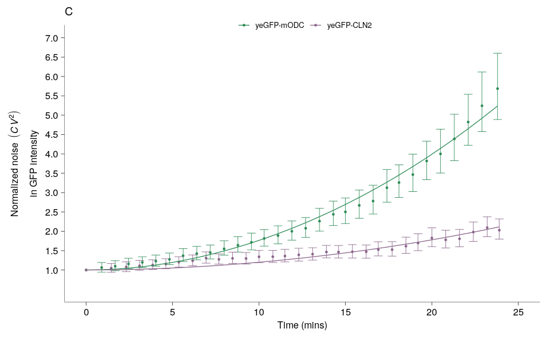

```r
trans.cvt.plt <- ci %>%
  bind_rows(.,ci.2) %>%
  mutate(image.no = as.numeric(image.no),
         degron = factor(degron, levels = c("yeGFP-mODC","yeGFP-CLN2"))) %>%
  left_join(.,mechanistic.cvt, by = c("degron","image.no")) %>%
  ggplot(.,aes(x = time.min, y = norm.cv2, color = degron, group = degron))+
  geom_point(size = 0.4)+
  geom_errorbar(aes(x=time.min, ymin=ci_lower, ymax= ci_upper),
                 width=0.5, size=0.2,
                 position = position_dodge(0.5),
                 )+
  geom_line(data = mechanistic.cvt, aes(x = time.min, y = opt.cv2),
            size = 0.3)+
  # facet_wrap(~degron)+
  scale_color_manual(values = c("seagreen4","plum4"), name = NULL)+
  theme_pubr()+
  theme(text = element_text(size = 8),
        strip.background = element_blank(),
        legend.background = element_blank(),
        legend.direction = "horizontal",
        legend.key.size = unit(4,"mm"),
        legend.position = c(0.5,1),
        axis.line = element_line(size = 0.1),
        axis.ticks = element_line(size = 0.2))+
  scale_x_continuous(breaks = c(0,5,10,15,20,25), limits = c(0,25))+
  scale_y_continuous(breaks = seq(1,7, by = 0.5), limits = c(0.5,7))+
  # ylab(TeX("Normalized noise $(\\textit{CV^2})$ in GFP intensity"))+
  # ylab(bquote(atop("Normalized noise" ~ italic(CV)), "in GFP intensity"))+
   ylab(bquote(atop("Normalized noise"~(italic(CV^2)), "in GFP intensity")))+
  xlab("Time (mins)")+
  labs(title = "C")
trans.cvt.plt
```

#CV of t.half and GFP ###bootsrapping

```r
#function
#cv in half life
cv.boot.fn <- function(data, i){
  data1 <- data %>%
    ungroup() %>%
    dplyr::select(dy, t.half)

  a1 <- data1[i,]

  cv <- sd(a1$t.half)/mean(a1$t.half)
  return(cv)
}

#cv in gfp
cv.gfp.boot.fn <- function(data, i){
  data1 <- data %>%
    ungroup()

  a1 <- data1[i,]

  cv <- sd(a1$gfp.mean.bg.af.sub.new)/mean(a1$gfp.mean.bg.af.sub.new)
  return(cv)
}
```

Running the bootstrap

```r
cv.gfp.ci
```

```
$`yeGFP-mODC`
BOOTSTRAP CONFIDENCE INTERVAL CALCULATIONS
Based on 2000 bootstrap replicates

CALL :
boot.ci(boot.out = b, conf = 0.95, type = "bca")

Intervals :
Level       BCa
95%   ( 0.3686,  0.4003 )
Calculations and Intervals on Original Scale

$`yeGFP-CLN2`
BOOTSTRAP CONFIDENCE INTERVAL CALCULATIONS
Based on 2000 bootstrap replicates

CALL :
boot.ci(boot.out = b, conf = 0.95, type = "bca")

Intervals :
Level       BCa
95%   ( 0.5167,  0.5589 )
Calculations and Intervals on Original Scale
```

#plotting CV in gfp intensity

```r
cv.gfp.boot.df <- cv.gfp.boot.lst %>%
  map(.,function(a){
    a %>%
      summary() %>% as.data.frame()
  }) %>%
  bind_rows(.id = "degron")


cv.gfp.ci.df <- cv.gfp.ci %>%
  map(.,function(a){
    data.frame(low.ci = a$`bca`[4],
               high.ci = a$`bca`[5])
  }) %>%
  bind_rows(.id = "degron")

cv.gfp.plt.df <- cv.gfp.boot.df %>%
  left_join(.,cv.gfp.ci.df, by = c("degron"))

#displaying the final df where low.ci = 25% percentile value, and high.ci = 95% percentile value of theCV in GFP intensities at t=0.
cv.gfp.plt.df %>%
  mutate_if(is.numeric, signif, digits = 2)
```

| degron | R | original | bootBias | bootSE | bootMed | low.ci | high.ci |
| --- | --- | --- | --- | --- | --- | --- | --- |
| yeGFP-mODC | 2000 | 0.38 | -3.8e-04 | 0.008 | 0.38 | 0.37 | 0.40 |
| yeGFP-CLN2 | 2000 | 0.54 | -9.2e-05 | 0.011 | 0.54 | 0.52 | 0.56 |

##plot = cv.gfp.plt

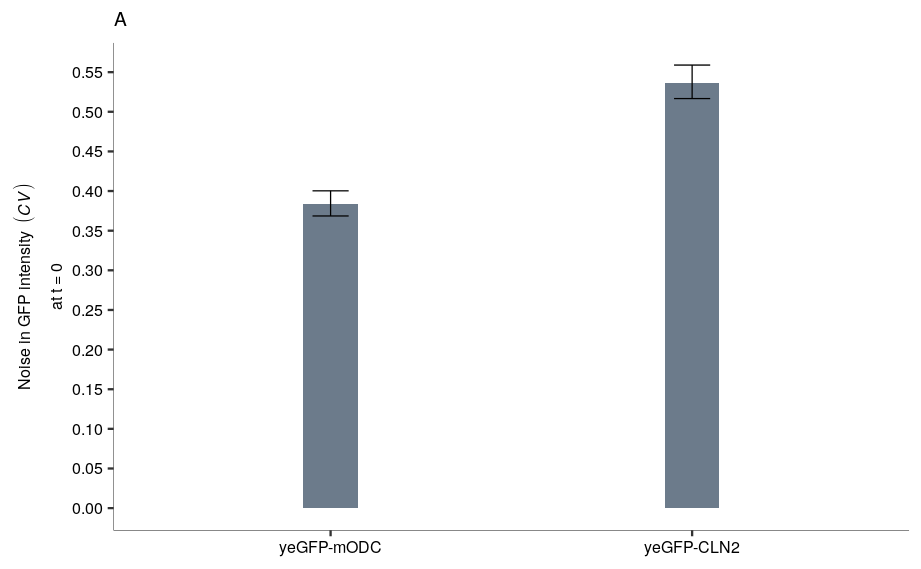

#plotting cv in half life

```r
cv.hl.boot.df <- cv.hl.boot.lst %>%
  map(.,function(a){
    a %>%
      summary() %>%
      as.data.frame()
  }) %>%
  bind_rows(.id = "degron")

cv.hl.ci.df <- cv.hl.ci %>%
  map(.,function(a){
    data.frame(ci.low = a$`bca`[4],
               ci.high = a$`bca`[5])
  }) %>%
  bind_rows(.id = "degron")

cv.halflife.fig.df <- cv.hl.boot.df %>%
  left_join(.,cv.hl.ci.df, by = c("degron"))
```

##plot: cv.hl.plt

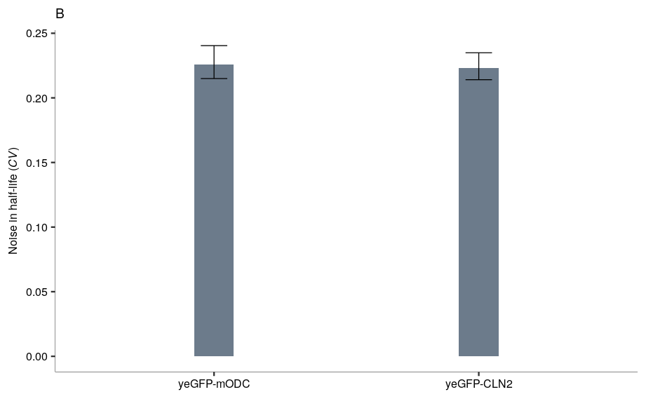

```r
cv.hl.plt <- cv.halflife.fig.df %>%
  mutate(degron = factor(degron, levels = c("yeGFP-mODC", "yeGFP-CLN2"))) %>%
  ggplot(.,aes(x =degron, y = original, fill = degron))+
  geom_col(width = 0.15, position = "dodge")+
  geom_errorbar( aes(x=degron, ymin=ci.low, ymax=ci.high),
                 width=0.1, size=0.3,
                 position = position_dodge(0.2))+
  theme_pubr()+
  theme(text = element_text(size = 8),
            legend.key.size = unit(4,"mm"),
        legend.position = "top",
        axis.line = element_line(size = 0.1),
        strip.background = element_blank(),
        axis.title.x = element_blank())+
  scale_fill_manual(values = c("slategray4", "slategray4"), name = NULL)+
  guides(fill = "none")+
  # scale_fill_manual(values = c("lightsteelblue4" ," steelblue4","gray"), name = NULL)+
  # scale_fill_brewer(palette = "Set2", name = "Replicate")+
  # scale_color_manual(values = c("black","black","black"))+
  guides(color = "none")+
  ylab(TeX("Noise in half-life (\\textit{CV})"))+
  labs(title = "B")+
  scale_y_continuous(breaks = seq(0,0.25, by = 0.05))

cv.hl.plt
```

#patchwork

```r
# t.1 <- reduc.gfp.plt
t.1<- cv.gfp.plt

t.2 <- cv.hl.plt

t <- (t.1|plot_spacer()|t.2)+
  plot_layout(widths = c(0.5,-0.08,0.5))
```

|  | t | l | b | r |
| --- | --- | --- | --- | --- |
| 1: | 1 | 1 | 1 | 1 |
| 2: | 1 | 2 | 1 | 2 |
| 3: | 1 | 3 | 1 | 3 |

```r
b <- trans.cvt.plt

tb <- (t/plot_spacer()/b)+
  plot_layout(heights = c(0.4,-0.08,0.6))
```

|  | t | l | b | r |
| --- | --- | --- | --- | --- |
| 1: | 1 | 1 | 1 | 1 |
| 2: | 1 | 2 | 1 | 2 |
| 3: | 1 | 3 | 1 | 3 |

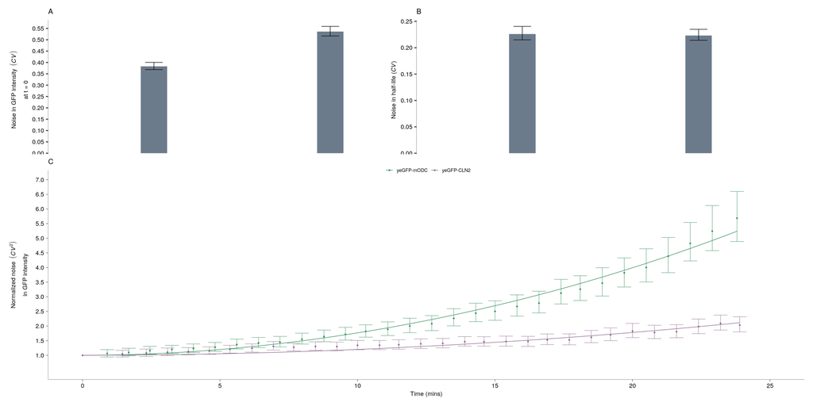

```r
tb
```

#saving the final figure

```r
ggsave(filename = "fig_noise.pdf", plot = tb, path = "../../../fig_pdfs/fig_noise/", width = 5, height = 4)
```

#Supp

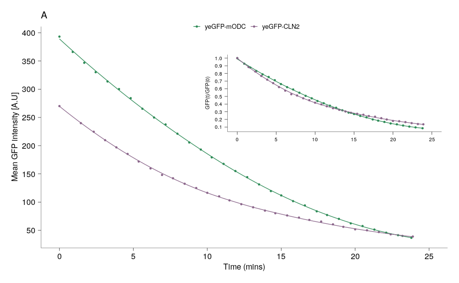

```r
reduc.gfp.plt
ggsave(filename = "Supfig_noise.png", plot = reduc.gfp.plt, path = "../../../fig_pdfs/Sfig_noise/",
       width = 4, height = 3.4)
ggsave(filename = "Supfig_noise.pdf", plot = reduc.gfp.plt, path = "../../../fig_pdfs/Sfig_noise/",
       width = 4, height = 3.4)
```

```r
write_rds(reduc.gfp.plt, "../../../fig_pdfs/Sfig_noise/Supfig_noise.rds")
```